# CS109A Introduction to Data Science

[figure not shown]

## Standard Section 4: Model Selection

**Harvard University**  
**Fall 2018**  
**Instructors:** Pavlos Protopapas, Kevin Rader  
**Section Leaders:** Mehul Smriti Raje, Ken Arnold, Karan Motwani, Cecilia Garraffo

# NYC Car Hire Dataset

Our goal, as in lecture, will be to predict taxi fares based on various other features of the ride.

For descriptions of what the columns mean, see http://www.nyc.gov/html/tlc/html/about/trip_record_data.shtml and data dictionaries there.

```python
# Instead of converting to datetime after loading, you can tell Pandas the datatypes you want while loading.
nyc_cab_df = pd.read_csv(
    'nyc_car_hire_data.csv',
    dtype={'Store_and_fwd_flag': str, 'Base': str},
    parse_dates=['lpep_pickup_datetime', 'Lpep_dropoff_datetime'])

nyc_cab_df['pickup_hour'] = nyc_cab_df.lpep_pickup_datetime.dt.hour
nyc_cab_df['dropoff_hour'] = nyc_cab_df.Lpep_dropoff_datetime.dt.hour

nyc_cab_df.head()
```

|  | AWND | Base | Day | Dropoff_latitude | Dropoff_longitude | Ehail_fee | Extra | Fare_amount | Lpep_dropoff_datetime | MTA_tax | PRCP | Passenger_count | Payment_type | Pickup_latitude | Pickup_longitude | RateCodeID | SNOW | SNWD | Store_and_fwd_flag | TMAX | TMIN | Tip_amount | Tolls_amount | Total_amount | Trip_distance | Trip_type | Type | VendorID | lpep_pickup_datetime | … |
| --- | --- | --- | --- | --- | --- | --- | --- | --- | --- | --- | --- | --- | --- | --- | --- | --- | --- | --- | --- | --- | --- | --- | --- | --- | --- | --- | --- | --- | --- | --- |
| 0 | 4.7 | B02512 | 1 | NaN | NaN | NaN | NaN | 33.863498 | 2014-04-01 00:24:00 | NaN | 0.0 | NaN | NaN | 40.7690 | -73.9549 | NaN | 0.0 | 0.0 | NaN | 60 | 39 | NaN | NaN | NaN | 4.083561 | NaN | 1 | NaN | 2014-04-01 00:11:00 | … |
| 1 | 4.7 | B02512 | 1 | NaN | NaN | NaN | NaN | 19.022892 | 2014-04-01 00:29:00 | NaN | 0.0 | NaN | NaN | 40.7267 | -74.0345 | NaN | 0.0 | 0.0 | NaN | 60 | 39 | NaN | NaN | NaN | 3.605694 | NaN | 1 | NaN | 2014-04-01 00:17:00 | … |
| 2 | 4.7 | B02512 | 1 | NaN | NaN | NaN | NaN | 25.498981 | 2014-04-01 00:34:00 | NaN | 0.0 | NaN | NaN | 40.7316 | -73.9873 | NaN | 0.0 | 0.0 | NaN | 60 | 39 | NaN | NaN | NaN | 4.221763 | NaN | 1 | NaN | 2014-04-01 00:21:00 | … |
| 3 | 4.7 | B02512 | 1 | NaN | NaN | NaN | NaN | 28.024628 | 2014-04-01 00:39:00 | NaN | 0.0 | NaN | NaN | 40.7588 | -73.9776 | NaN | 0.0 | 0.0 | NaN | 60 | 39 | NaN | NaN | NaN | 2.955510 | NaN | 1 | NaN | 2014-04-01 00:28:00 | … |
| 4 | 4.7 | B02512 | 1 | NaN | NaN | NaN | NaN | 12.083589 | 2014-04-01 00:40:00 | NaN | 0.0 | NaN | NaN | 40.7594 | -73.9722 | NaN | 0.0 | 0.0 | NaN | 60 | 39 | NaN | NaN | NaN | 1.922292 | NaN | 1 | NaN | 2014-04-01 00:33:00 | … |

Let's have a quick look at the data before we get started. (We really should do more than this, but skipping that for time.)

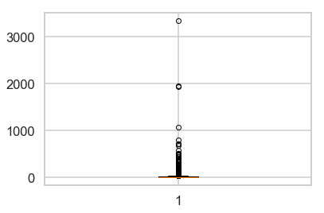

```python
plt.boxplot(nyc_cab_df.Fare_amount);
```

# Let's work with a subset of this data for now.

```python
# TODO: some useful predictors may be missing, but maybe because they have missing data.
# nyc_cab_df.columns.difference(all_predictors)
all_predictors = ['Trip Length (min)', 'Type', 'Trip_distance', 'TMAX', 'TMIN',
                  'pickup_hour', 'dropoff_hour', 'Pickup_longitude',
                  'Pickup_latitude', 'SNOW', 'SNWD', 'PRCP']

sample_frac = .01
shuffled = nyc_cab_df_clean.sample(frac=sample_frac, random_state=0)[all_predictors + ['Fare_amount']]
shuffled.shape

n_total = len(shuffled)
n_test = int(n_total * .2)
n_valid = int(n_total * .2)
n_train = n_total - n_valid - n_test

train = shuffled.iloc[:n_train].copy()
valid = shuffled.iloc[n_train:n_train + n_valid].copy()
test = shuffled.iloc[n_train + n_valid:].copy()
assert len(train) == n_train
assert len(valid) == n_valid
assert len(test) == n_test
print(f"{n_train} train, {n_valid} validation, {n_test} test.")
```

```
11183 train, 3727 validation, 3727 test.
```

```python
train.info()
```

```
<class 'pandas.core.frame.DataFrame'>
Int64Index: 11183 entries, 959269 to 686097
Data columns (total 13 columns):
Trip Length (min)    11183 non-null float64
Type                 11183 non-null int64
Trip_distance        11183 non-null float64
TMAX                 11183 non-null int64
TMIN                 11183 non-null int64
pickup_hour          11183 non-null int64
dropoff_hour         11183 non-null int64
Pickup_longitude     11183 non-null float64
Pickup_latitude      11183 non-null float64
SNOW                 11183 non-null float64
SNWD                 11183 non-null float64
PRCP                 11183 non-null float64
Fare_amount          11183 non-null float64
dtypes: float64(8), int64(5)
memory usage: 1.2 MB
```

# Scaling / Normalization

Warm-up exercise: for which of the following do the units of the predictors matter (e.g., trip length in minutes vs seconds; temperature in F or C)?

- k-NN (Nearest Neighbors regression)
- Linear regression
- Lasso regression
- Ridge regression
- kNN: **yes**. Scaling affects distance metric, which determines what "neighbor" means
- Linear regression: **no**. Multiply predictor by $c$ -> divide coef by $c$.
- Lasso: **yes**: If we divided coef by $c$, then corresponding penalty term is also divided by $c$.
- Ridge: **yes**: Same as Lasso, except penalty divided by $c^2$.

Remember that the mean and variance used to scale data are parameters that need to be learned from our training data.

```python
from sklearn.preprocessing import StandardScaler

scaler = StandardScaler().fit(train[all_predictors])

pd.DataFrame({
    'mean': scaler.mean_,
    'variance': scaler.var_
}, index=all_predictors).T
```

|  | Trip Length (min) | Type | Trip_distance | TMAX | TMIN | pickup_hour | dropoff_hour | Pickup_longitude | Pickup_latitude | SNOW | SNWD | PRCP |
| --- | --- | --- | --- | --- | --- | --- | --- | --- | --- | --- | --- | --- |
| mean | 11.330680 | 0.300009 | 2.875462 | 60.886167 | 43.269874 | 13.980148 | 13.978897 | -73.879007 | 40.718952 | 0.0 | 0.0 | 0.336174 |
| variance | 61.431918 | 0.210004 | 5.458100 | 70.157211 | 36.335824 | 42.114960 | 43.055980 | 4.887413 | 1.486695 | 0.0 | 0.0 | 1.105074 |

```python
# Scaling in place... not my favorite approach
for df in [train, valid, test]:
    df[all_predictors] = scaler.transform(df[all_predictors])
```

```python
train[all_predictors].describe()
```

|  | Trip Length (min) | Type | Trip_distance | TMAX | TMIN | pickup_hour | dropoff_hour | Pickup_longitude | Pickup_latitude | SNOW | SNWD | PRCP |
| --- | --- | --- | --- | --- | --- | --- | --- | --- | --- | --- | --- | --- |
| count | 1.118300e+04 | 1.118300e+04 | 1.118300e+04 | 1.118300e+04 | 1.118300e+04 | 1.118300e+04 | 1.118300e+04 | 1.118300e+04 | 1.118300e+04 | 11183.0 | 11183.0 | 1.118300e+04 |
| mean | -8.895286e-17 | -8.895286e-18 | 1.105557e-16 | -2.265121e-16 | -5.534139e-16 | -5.511900e-17 | 1.906133e-17 | -4.778039e-16 | 3.429768e-15 | 0.0 | 0.0 | -9.530664e-18 |
| std | 1.000045e+00 | 1.000045e+00 | 1.000045e+00 | 1.000045e+00 | 1.000045e+00 | 1.000045e+00 | 1.000045e+00 | 1.000045e+00 | 1.000045e+00 | 0.0 | 0.0 | 1.000045e+00 |
| min | -1.445636e+00 | -6.546676e-01 | -1.230798e+00 | -1.657854e+00 | -2.035507e+00 | -2.154238e+00 | -2.130375e+00 | -2.332211e-01 | -3.339532e+01 | 0.0 | 0.0 | -3.197923e-01 |
| 25% | -6.801201e-01 | -6.546676e-01 | -6.615118e-01 | -8.221316e-01 | -5.424547e-01 | -7.674041e-01 | -7.587809e-01 | -4.550192e-02 | -3.110732e-04 | 0.0 | 0.0 | -3.197923e-01 |
| 50% | -1.697762e-01 | -6.546676e-01 | -2.420375e-01 | 1.359045e-02 | -4.477065e-02 | 1.571516e-01 | 3.080150e-01 | -3.345387e-02 | 2.595593e-02 | 0.0 | 0.0 | -3.197923e-01 |
| 75% | 3.405678e-01 | 1.527493e+00 | 3.186884e-01 | 7.299237e-01 | 4.529134e-01 | 7.735220e-01 | 7.652132e-01 | -1.930459e-02 | 6.536592e-02 | 0.0 | 0.0 | -2.532033e-01 |
| max | 5.954351e+00 | 1.527493e+00 | 8.113206e+00 | 1.923812e+00 | 2.609544e+00 | 1.389892e+00 | 1.374811e+00 | 3.341808e+01 | 3.855061e-01 | 0.0 | 0.0 | 4.408025e+00 |

```python
train.Fare_amount.describe()
```

```
count    11183.000000
mean        14.650476
std          8.598972
min          0.010000
25%          7.500000
50%         13.000000
75%         20.014209
max         52.500000
Name: Fare_amount, dtype: float64
```

# Nearest-Neighbors Regression: How many neighbors should we use?

```python
k_vals = [1, 5, 10, 15, 20, 25, 30, 35, 40, 50, 60]
knns = {
    k: KNeighborsRegressor(n_neighbors=k).fit(
        train[all_predictors], train.Fare_amount)
    for k in k_vals}

train_r2s = [
    metrics.r2_score(train.Fare_amount, model.predict(train[all_predictors]))
    for k, model in knns.items()]
```

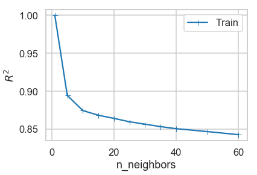

```python
plt.plot(k_vals, train_r2s, '-+', label="Train")
plt.xlabel('n_neighbors')
plt.ylabel("$R^2$")
plt.legend();
```

Which n_neighbors should we choose?

## What's our goal?

Do best on *unseen* data.

## Validation set is currently unseen.

So let's see how well our models do on it.

```python
val_r2s = [
    metrics.r2_score(valid.Fare_amount, model.predict(valid[all_predictors]))
    for k, model in knns.items()]
```

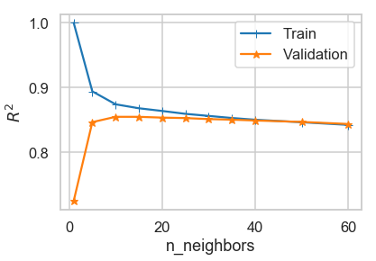

```python
plt.plot(k_vals, train_r2s, '-+', label="Train")
plt.plot(k_vals, val_r2s, '-*', label="Validation")
plt.xlabel('n_neighbors')
plt.ylabel("$R^2$")
plt.legend();
```

Now, which n_neighbors should we choose?

```python
best_r2_idx = np.argmax(val_r2s)
best_r2 = val_r2s[best_r2_idx]
best_n_neighbors = k_vals[best_r2_idx]
print(f"Best n_neighbors is {best_n_neighbors}, which gives a validation R^2 of {best_r2:.3f}")
```

```
Best n_neighbors is 10, which gives a validation R^2 of 0.855
```

How confident are we about that choice? What if there was something unusual about our particular validation set?

How could we gain more confidence?

# Cross-Validation

If we repeat an experiment and the results say the same thing, we get more confident in that result. *How could we repeat this experiment?*

Let's choose different subsets of our data as our training and validation sets.

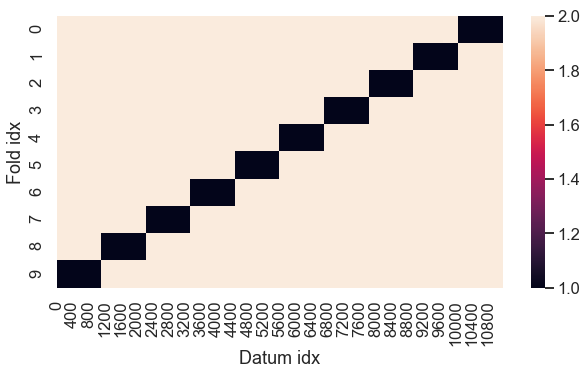

```python
from sklearn.model_selection import KFold
n_splits = 10
folds = np.zeros((n_splits, len(train)))
fake_dataset = np.arange(len(train))
for fold_idx, (train_indices, valid_indices) in enumerate(KFold(n_splits=n_splits).split(fake_dataset)):
    folds[fold_idx, train_indices] = 2
    folds[fold_idx, valid_indices] = 1
fig, ax = plt.subplots(figsize=(10, 5))
sns.heatmap(folds[::-1], ax=ax) # TODO: label this better!
ax.set(xlabel="Datum idx", ylabel="Fold idx");
```

Cross-Validation core

```python
X = train[all_predictors]
y = train.Fare_amount
```

```python
n_neighbors = 10 # for example
cv = KFold(n_splits=10)
cv_r2 = []
for fold_idx, (train_indices, valid_indices) in enumerate(cv.split(X)):
    # Train on training set.
    model = KNeighborsRegressor(n_neighbors=n_neighbors)
    model.fit(X.iloc[train_indices], y.iloc[train_indices])

    # Evaluate on validation set.
    val_predictions = model.predict(X.iloc[valid_indices])
    val_r2 = metrics.r2_score(y.iloc[valid_indices], val_predictions)

    cv_r2.append(val_r2)
```

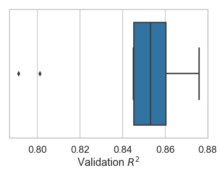

```python
sns.boxplot(cv_r2); plt.xlabel("Validation $R^2$");
```

Now do this for each candidate n_neighbors!

```python
def cross_validate_knn(X, y, n_splits, k_vals):
    cv_results = []
    cv = KFold(n_splits=n_splits)

    # Outer loop: pick n_neighbors
    for n_neighbors in k_vals:

        # Inner loop: pick train and validation sets.
        for fold_idx, (train_indices, valid_indices) in enumerate(cv.split(X)):
            # Train on training set.
            model = KNeighborsRegressor(n_neighbors=n_neighbors)
            model.fit(X.iloc[train_indices], y.iloc[train_indices])

            # Evaluate on validation set. I include MSE here just to show how.
            val_predictions = model.predict(X.iloc[valid_indices])
            val_r2 = metrics.r2_score(y.iloc[valid_indices], val_predictions)
            val_mse = metrics.mean_squared_error(y.iloc[valid_indices], val_predictions)

            cv_results.append(dict(
                fold_idx=fold_idx,
                n_neighbors=n_neighbors,
                val_r2=val_r2,
                val_mse=val_mse
            ))
    return pd.DataFrame(cv_results)
cv_results = cross_validate_knn(X, y, n_splits=10, k_vals=k_vals)
cv_results.head(11)
```

|  | fold_idx | n_neighbors | val_mse | val_r2 |
| --- | --- | --- | --- | --- |
| 0 | 0 | 1 | 19.582487 | 0.751775 |
| 1 | 1 | 1 | 17.710063 | 0.743087 |
| 2 | 2 | 1 | 17.890290 | 0.739744 |
| 3 | 3 | 1 | 15.108882 | 0.790357 |
| 4 | 4 | 1 | 21.316752 | 0.713888 |
| 5 | 5 | 1 | 15.927632 | 0.773481 |
| 6 | 6 | 1 | 16.262528 | 0.774167 |
| 7 | 7 | 1 | 16.395153 | 0.789799 |
| 8 | 8 | 1 | 19.922931 | 0.728344 |
| 9 | 9 | 1 | 16.710313 | 0.795838 |
| 10 | 0 | 5 | 12.751734 | 0.838361 |

```python
# Make a table of the validation R^2 data, where each row is a different fold.
val_r2_table = cv_results.pivot(index='fold_idx', columns='n_neighbors', values='val_r2')
# alternative: cv_results.set_index(['fold_idx', 'n_neighbors']).val_r2.unstack(level=1)
val_r2_table
```

| n_neighbors fold_idx | 1 | 5 | 10 | 15 | 20 | 25 | 30 | 35 | 40 | 50 | 60 |
| --- | --- | --- | --- | --- | --- | --- | --- | --- | --- | --- | --- |
| 0 | 0.751775 | 0.838361 | 0.846247 | 0.848543 | 0.846561 | 0.845755 | 0.843973 | 0.844033 | 0.840830 | 0.837155 | 0.834562 |
| 1 | 0.743087 | 0.829843 | 0.853299 | 0.858193 | 0.857334 | 0.856293 | 0.854176 | 0.853082 | 0.851862 | 0.849573 | 0.847336 |
| 2 | 0.739744 | 0.851182 | 0.859116 | 0.861349 | 0.863230 | 0.860448 | 0.860142 | 0.857826 | 0.855546 | 0.852625 | 0.849647 |
| 3 | 0.790357 | 0.855258 | 0.860757 | 0.863444 | 0.862979 | 0.862656 | 0.860542 | 0.858673 | 0.859154 | 0.855150 | 0.851734 |
| 4 | 0.713888 | 0.785308 | 0.791115 | 0.797459 | 0.797057 | 0.794462 | 0.792262 | 0.789779 | 0.788168 | 0.783295 | 0.780932 |
| 5 | 0.773481 | 0.842808 | 0.852990 | 0.859311 | 0.862505 | 0.858309 | 0.855681 | 0.854264 | 0.853136 | 0.849946 | 0.846897 |
| 6 | 0.774167 | 0.832477 | 0.844946 | 0.843760 | 0.844797 | 0.843010 | 0.841472 | 0.839870 | 0.838088 | 0.835430 | 0.832205 |
| 7 | 0.789799 | 0.855152 | 0.860794 | 0.860559 | 0.861657 | 0.859818 | 0.856437 | 0.854543 | 0.852385 | 0.850082 | 0.846750 |
| 8 | 0.728344 | 0.788996 | 0.800917 | 0.801670 | 0.800536 | 0.799309 | 0.798490 | 0.796204 | 0.794484 | 0.790631 | 0.789120 |
| 9 | 0.795838 | 0.871517 | 0.875833 | 0.874913 | 0.875388 | 0.874800 | 0.874535 | 0.873019 | 0.871999 | 0.869174 | 0.865932 |

Let's visualize that data, 3 different ways.

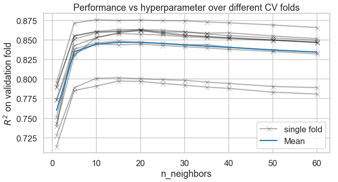

```python
fig, ax = plt.subplots(figsize=(10, 5))
for fold_idx, row in val_r2_table.iterrows():
    ax.plot(row.index, row.values, '-x', c='black', alpha=.3, label="single fold" if fold_idx is 0 else None)
# plt.plot(row.index, val_r2_table.mean(axis=0), c='white', linewidth=5)
ax.plot(row.index, val_r2_table.mean(axis=0), label='Mean')
ax.legend()
ax.set(xlabel="n_neighbors", ylabel="$R^2$ on validation fold", title="Performance vs hyperparameter over different CV folds");
```

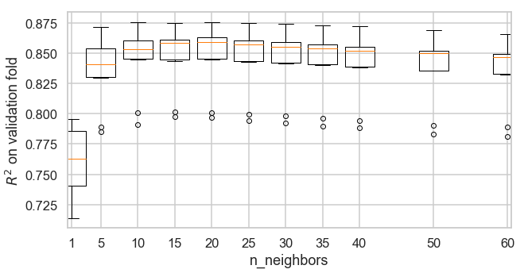

```python
fig, ax = plt.subplots(figsize=(10, 5))
ax.boxplot(val_r2_table.values, positions=k_vals, widths=4);
ax.set(xlabel="n_neighbors", ylabel="$R^2$ on validation fold");
```

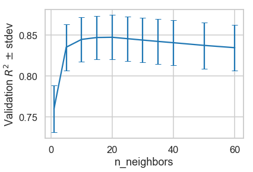

```python
cv_r2_mean = cv_results.groupby('n_neighbors').val_r2.mean()
cv_r2_std = cv_results.groupby('n_neighbors').val_r2.std()
plt.errorbar(k_vals, cv_r2_mean, yerr=cv_r2_std, capsize=5)
plt.gca().set(xlabel="n_neighbors", ylabel="Validation $R^2$ $\pm$ stdev");
```

Now, which n_neighbors should you choose?

# Make a final model with our optimal hyperparameter value

For now, let's use the model with the best mean CV performance.

```python
best_n_neighbors = cv_r2_mean.idxmax()
estimated_r2_best = cv_r2_mean[best_n_neighbors]
print("The best n_neighbors is {}, with estimated R^2 = {:.2f} +- {:.2f}".format(
      best_n_neighbors, estimated_r2_best, cv_r2_std[best_n_neighbors]))
```

```
The best n_neighbors is 20, with estimated R^2 = 0.85 +- 0.03
```

```python
all_my_data = pd.concat([train, valid])
my_best_model = (
    KNeighborsRegressor(n_neighbors=best_n_neighbors)
    .fit(all_my_data[all_predictors], all_my_data.Fare_amount))
assert len(train) + len(valid) == len(all_my_data)
print(f"Trained a new model on {len(train)} + {len(valid)} = {len(all_my_data)} samples.")
```

```
Trained a new model on 11183 + 3727 = 14910 samples.
```

# How well does this model perform on unseen data?

We've already looked at *train* and *validation*. Only *test* remains completely unseen. The point of no return...

```python
print(f"We expect our best model to get an R^2 of {estimated_r2_best:.3f}, or even better because we have more data now.")
print("Drumroll please...")
```

```
We expect our best model to get an R^2 of 0.847, or even better because we have more data now.
Drumroll please...
```

```python
test_predictions = my_best_model.predict(test[all_predictors])
test_r2 = metrics.r2_score(test.Fare_amount, test_predictions)
print(f"Our best model got an R^2 of {test_r2:.3f}.")
```

```
Our best model got an R^2 of 0.817.
```

btw, when I first ran this, the test R^2 was *much* worse, ~0.5. But I figured out why. Can you?

It turns out that the *test* set happened to have some enormous outliers.

# Same approach works for penalized regression!

```python
def cross_validate_general(train_model, X, y, n_splits, params):
    cv_results = []
    cv = KFold(n_splits=n_splits)

    # Outer loop: pick hyperparameter setting.
    for param_setting in params:

        # Inner loop: pick train and validation sets.
        for fold_idx, (train_indices, valid_indices) in enumerate(cv.split(X, y)):
            # Train on training set.
            model = train_model(X[train_indices], y[train_indices], param_setting)

            # Evaluate on validation set.
            val_predictions = model.predict(X[valid_indices])
            val_r2 = metrics.r2_score(y[valid_indices], val_predictions)
            val_mse = metrics.mean_squared_error(y[valid_indices], val_predictions)

            cv_results.append(dict(
                param_setting,
                fold_idx=fold_idx,
                val_r2=val_r2,
                val_mse=val_mse
            ))
    return pd.DataFrame(cv_results)

def train_lasso(X, y, params):
    return Lasso(alpha=params['alpha']).fit(X, y)


X = train[all_predictors].values
y = train.Fare_amount.values

params = [{'alpha': alpha} for alpha in [.1, 1., 10.]]
cv_results = cross_validate_general(
    train_model=train_lasso,
    X=X, y=y,
    n_splits=10, params=params)

agg_cv_results = cv_results.groupby('alpha').val_r2.agg(['mean', 'std'])
agg_cv_results
```

| alpha | mean | std |
| --- | --- | --- |
| 0.1 | 0.844775 | 0.031353 |
| 1.0 | 0.813970 | 0.026487 |
| 10.0 | -0.001185 | 0.001649 |

```python
best_alpha = agg_cv_results['mean'].idxmax()
estimated_r2 = agg_cv_results['mean'][best_alpha]
best_model = Lasso(alpha=best_alpha).fit(X, y)
test_predictions = best_model.predict(test[all_predictors].values)
test_r2 = metrics.r2_score(test.Fare_amount, test_predictions)
print(f"Best alpha was {best_alpha}, with estimated R^2 of {estimated_r2:.3f}.")
print(f"Training this on all data gives a test R^2 of {test_r2:.3f}")
```

```
Best alpha was 0.1, with estimated R^2 of 0.845.
Training this on all data gives a test R^2 of 0.803
```

```python
# We could also use a meta-estimator from sklearn.
# But make sure you understand all of what's going on in the above first!
from sklearn.model_selection import GridSearchCV

gridsearch_model = GridSearchCV(
    estimator=Lasso(),
    param_grid=[{'alpha': [.1, 1., 10.]}],
    cv=KFold(n_splits=10),
    scoring='r2',
    return_train_score=False)
gridsearch_model.fit(X, y)
pd.DataFrame(gridsearch_model.cv_results_).set_index('param_alpha')
```

| param_alpha | mean_fit_time | std_fit_time | mean_score_time | std_score_time | params | split0_test_score | split1_test_score | split2_test_score | split3_test_score | split4_test_score | split5_test_score | split6_test_score | split7_test_score | split8_test_score | split9_test_score | mean_test_score | std_test_score | rank_test_score |
| --- | --- | --- | --- | --- | --- | --- | --- | --- | --- | --- | --- | --- | --- | --- | --- | --- | --- | --- |
| 0.1 | 0.003266 | 0.000358 | 0.000361 | 0.000062 | {'alpha': 0.1} | 0.848971 | 0.852551 | 0.857965 | 0.864766 | 0.780191 | 0.863877 | 0.843819 | 0.856511 | 0.797919 | 0.881180 | 0.844777 | 0.029740 | 1 |
| 1.0 | 0.003307 | 0.000465 | 0.000416 | 0.000087 | {'alpha': 1.0} | 0.815950 | 0.819903 | 0.823129 | 0.838299 | 0.761552 | 0.825254 | 0.812359 | 0.825485 | 0.773266 | 0.844504 | 0.813972 | 0.025125 | 2 |
| 10.0 | 0.002045 | 0.000293 | 0.000298 | 0.000066 | {'alpha': 10.0} | -0.000373 | -0.000410 | -0.001153 | -0.000108 | -0.000075 | -0.005123 | -0.000034 | -0.002568 | -0.000001 | -0.002008 | -0.001185 | 0.001564 | 3 |

```python
# It also refits the model on the full dataset, so we get the same test R^2.
gridsearch_model.score(test[all_predictors], test.Fare_amount)
```

```
0.803262478581998
```